# Python for data Science Project

## Project Description

This project will explain the development of a Machine learning model step by step. The dataset we will be working with is an MLB pitching statistics from the official site **MLB Savant, https://baseballsavant.mlb.com/statcast_search** .

Now days with the technology available, the sports industry has evolved and most, if not all, of plays are being tracked by sensors and cameras, recopilating that data is gold for the teams, as it allows them to analyse players performance, field conditions, etc, and take smarter desitions based on data. One particular field of interes for MLB teams is pitching performance, is a very important topic not only for the teams, but also for the fans. Most brodcast chanels show pitching stats on live games that allows users to better understand the game, one specific stat is the **pitch type** (shown most of the times on the top corner) It indicates and classifies the pitch thrown by the pithcer (Fastball, Cutter, Slider, etc) each pith has a peculiar moevement that allows them to "classifiy/name" the pitch as shown in the next video.  
**Pitch moevment:** https://www.youtube.com/shorts/tPX76PGNYZU  
**pitch type:** https://www.youtube.com/watch?v=s0woX8UVvY4&t=32s

## Project objective

This project aims to develop a **classification** model, **the main objective is to assign the correct name to each pitch based on the metrics collected by the sensors on the field.** We know that every team measures features of the pitch like the speed, spin rate, break angle, etc. All of this information is available on the **MLB Savant** website, using that information, the model will have to correctlly classify and "name" the pitch.

## Dataset Description

As we will se later **MLB Savant** keeps track of all the events that occure on the field, but we are only interested on the pitching events, in other words, how the ball is traveling from the pitchers hand to home plate. This dataset contains multiple features, will dig dipper later, for every pitch thrown in every official game, so as you can imagine, we have a couple of thowsands rows of data to play with. This features are the once use by the MLB in their sistems to classify the pitches, so we have what we need to work here.

## Libraries

```python
# Install packages
# https://github.com/jldbc/pybaseball
!pip install pybaseball
```

```python
# Data modeling and processing
import pandas as pd
import numpy as np

# Dataset
import pybaseball as bb

# visualization and exploration
import seaborn as sns
import matplotlib.pyplot as plt

# Model
from sklearn.model_selection import train_test_split   # Split the dataset
from sklearn.ensemble import RandomForestClassifier    # Feature ranking
from sklearn.linear_model import LogisticRegression    # Classification model
from sklearn.ensemble import RandomForestClassifier    # Classification model
from sklearn.metrics import log_loss, accuracy_score   # Metrics for the model
from sklearn import preprocessing                      # Scale the values
```

# Load the databaset

This python package allow us to query data using the indicated timestamp.

```python
# download dataset
df = bb.statcast(start_dt='2022-01-01', end_dt='2022-07-01')
```

## Export initial dataset

We will export the initial dataset to a .csv file, so we can access it more efficiently in the future.

```python
# Export the dataset to load it offline
df.to_csv("MLB_pitches.csv")
```

## Load CSV dataset

Load the dataset from the CSV exported (Only if not already loaded)

```python
file_path = './MLB_pitches.csv'
df = pd.read_csv(file_path, delimiter=',', header=0, skiprows=None)
```

```python
df.head()
```

|  | Unnamed: 0 | pitch_type | game_date | release_speed | release_pos_x | release_pos_z | player_name | batter | pitcher | events | ... | fld_score | post_away_score | post_home_score | post_bat_score | post_fld_score | if_fielding_alignment | of_fielding_alignment | spin_axis | delta_home_win_exp | delta_run_exp |
| --- | --- | --- | --- | --- | --- | --- | --- | --- | --- | --- | --- | --- | --- | --- | --- | --- | --- | --- | --- | --- | --- |
| 0 | 3113 | KC | 2022-07-01 | 87.6 | -2.64 | 5.61 | Robertson, David | 646240 | 502085 | field_out | ... | 6 | 5 | 6 | 5 | 6 | Infield shift | Strategic | 37.0 | 0.035 | -0.099 |
| 1 | 3248 | KC | 2022-07-01 | 87.2 | -2.68 | 5.59 | Robertson, David | 680776 | 502085 | field_out | ... | 6 | 5 | 6 | 5 | 6 | Standard | Standard | 45.0 | 0.052 | -0.148 |
| 2 | 3338 | KC | 2022-07-01 | 86.5 | -2.60 | 5.65 | Robertson, David | 680776 | 502085 | NaN | ... | 6 | 5 | 6 | 5 | 6 | Standard | Standard | 38.0 | 0.000 | -0.031 |
| 3 | 3487 | KC | 2022-07-01 | 87.0 | -2.63 | 5.64 | Robertson, David | 680776 | 502085 | NaN | ... | 6 | 5 | 6 | 5 | 6 | Standard | Strategic | 35.0 | 0.000 | 0.023 |
| 4 | 3591 | FC | 2022-07-01 | 93.9 | -2.46 | 5.73 | Robertson, David | 608701 | 502085 | field_out | ... | 6 | 5 | 6 | 5 | 6 | Standard | Standard | 191.0 | 0.071 | -0.158 |

5 rows × 93 columns

# Exploratory analysis

On this section we will start exploring the dataset, see with what data are we gonna be working with, get familiar with it and understand it. This is a very important step because this will allow us to understand how to prepare the data in the proper way for the model and obtain the best result.

We are going to start by looking at all the columns of the dataset. As we can observe some of the columns have missing values, others do not contain data at all like spin_rate_deprecated, another important feature to observe is the data type of each column.

```python
df.info()
```

```
<class 'pandas.core.frame.DataFrame'>
RangeIndex: 390781 entries, 0 to 390780
Data columns (total 93 columns):
 #   Column                           Non-Null Count   Dtype
---  ------                           --------------   -----
 0   Unnamed: 0                       390781 non-null  int64
 1   pitch_type                       366347 non-null  object
 2   game_date                        390781 non-null  object
 3   release_speed                    366302 non-null  float64
 4   release_pos_x                    366308 non-null  float64
 5   release_pos_z                    366308 non-null  float64
 6   player_name                      390781 non-null  object
 7   batter                           390781 non-null  int64
 8   pitcher                          390781 non-null  int64
 9   events                           106824 non-null  object
```

[output cut: 85 more lines]

## Expert knowledge filter dataset

As we can observe, the dataset is populated with a lot of features that are useful for the MLB teams to keep track of the situation of the game, but most of them are not useful for our model.

In order to reduce the number of features we first apply a "Expert knowledge filter" to this dataset, that is, someone with experience on the game and pitching (me) has a really good idea of what features are possible to have an impact on the prediction of the pitch. In this step the so called "expert" must to be careful of not removing posible features with strong prediction/classification power in our model. Features like, the date of the game, the name of the players, the score of the game, etc. Are mot really important to classify the pitch, thats why, we will stick with the most promising features listed bellow:

Labels:

- **pitch_name and pitch_type** : This is our objective, the pitch type threw by the pitcher (are the same, so we only keep pitch_name).

Promising features:

- **release_speed** : Initial velocity of the pitch.
- **release_pos_x / release_pos_z** : Release point of the pitch (2D).
- **p_trows** : Indicates if the pitcher is lefty or righty (important because of the spin direction of the ball).
- **pfx_x / pfx_x** : Break (movement) of the ball during the trajectory (2D).
- **spin_axis** : Axis of rotation of the ball.
- **release_spin_rate** : Spin rate at the moment of release

```python
# Filter only the promising features
df_filt = df[["pitch_name", "release_speed", "release_pos_x", "release_pos_z", "p_throws", "pfx_x", "pfx_z", "spin_axis", "release_spin_rate"]]
```

```python
# New dataset
df_filt.head()
```

|  | pitch_name | release_speed | release_pos_x | release_pos_z | p_throws | pfx_x | pfx_z | spin_axis | release_spin_rate |
| --- | --- | --- | --- | --- | --- | --- | --- | --- | --- |
| 0 | Knuckle Curve | 87.6 | -2.64 | 5.61 | R | 0.30 | -0.96 | 37.0 | 2769.0 |
| 1 | Knuckle Curve | 87.2 | -2.68 | 5.59 | R | 0.39 | -0.79 | 45.0 | 2622.0 |
| 2 | Knuckle Curve | 86.5 | -2.60 | 5.65 | R | 0.31 | -1.10 | 38.0 | 2701.0 |
| 3 | Knuckle Curve | 87.0 | -2.63 | 5.64 | R | 0.50 | -0.99 | 35.0 | 2597.0 |
| 4 | Cutter | 93.9 | -2.46 | 5.73 | R | -0.09 | 1.59 | 191.0 | 2702.0 |

# Features exploration

Now with only the promising features we are going to start exploring them and understand the data we are working with.

## Pitches classification objective

Observing at the pitches distribution we have a better idea about what pitches our model will be able to classify better. As we can see, the 4-seam fastball is the prefer pitch type, but after the cutter we see that the other pitches are no so commonly thrown.

Here we have an important piece of information, the pitches with less information or concurrencies are going to be harder to classify correctly because the model is not going to be able to "learn" the characteristics of them, one posible option to this problem is to exclude those type of pitches from the prediction list and work only with the most concurrent once:

List of pitches to predict:

- 4-Seam Fastball
- Slider
- Sinker
- Changeup
- Curveball
- Cutter

This, form a "Bussines/Experts" point of view, is a good starting point, most of the pitchers have this types of pitches in their roster and is very uncommon to have a pithcer throwing a knuckleball (1 or 2 in all the leage with more than 150 pitchers).

**Pitch types description:** https://www.mlb.com/glossary/pitch-types

```
4-Seam Fastball    123677
Slider              66517
Sinker              54906
Changeup            42650
Curveball           27640
Cutter              25515
Sweeper             10207
Knuckle Curve        7251
Split-Finger         5825
Slurve               1247
Other                 595
Eephus                193
Slow Curve             75
Pitch Out              18
Screwball              17
Knuckleball            14
Name: pitch_name, dtype: int64
```

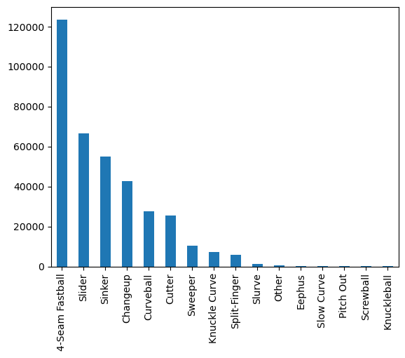

```python
df_filt["pitch_name"].value_counts().plot(kind="bar")
df_filt["pitch_name"].value_counts()
```

The 6 selected pitches are more than **90%** of the pitches thrown in a regular season, so we are well covered for a classification model using those pitches as a first iteration.

```python
df_filt["pitch_name"].value_counts(normalize=True).head(6).sum() * 100
```

```
93.05521814017858
```

## Selected pitches

```python
# Filter of pithc types
df_pitches = df_filt[df_filt["pitch_name"].isin(["4-Seam Fastball", "Slider", "Sinker", "Changeup", "Curveball", "Cutter"])]
```

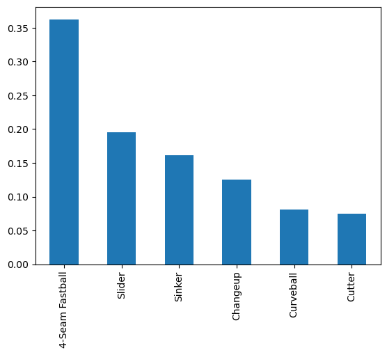

```python
df_pitches["pitch_name"].value_counts(normalize=True).plot(kind="bar")
```

# Feature exploration

To explore the features of the dataset, we are going to explore only a sample of the entire dataset, this will give us an idea of the behavior of the full dataset without needing to spend mutch computational power on his step.

```python
sample_exp = df_pitches.sample(1000)
```

## Feature correlation

The next figure shows the correlation matrix for the proposed features for a sub sample of right hand side pitcher. We can observe the following facts:

- **Strong correlation** between **speed** and multiple other features like **breake of the ball** (both X and Z) and the **spin axis**
- **Strong correlation** between **spin axis** and **break** (both X and Z), *the more the ball spins the more it can break..*
- Also observe features with **not so strong correlation** with the others like the **release position (both X and Z)**

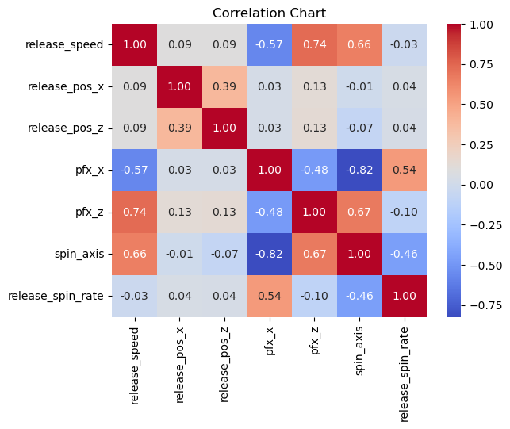

```python
# Sample of right hand pitcher
sample_exp_right = sample_exp[sample_exp["p_throws"] == "R"]

# Plot
correlation_matrix = sample_exp_right.corr()
sns.heatmap(correlation_matrix, annot=True, cmap='coolwarm', fmt=".2f")
plt.title('Correlation Chart')
plt.show()
```

## Feature correlation

Lets dig deeper on the two higher correlations **release_speed - pfx_z** and **spin_axis - pfx_x** . We observe that there is a strong linear relation between the release_speed and the pfx_z.

Here we observe a strong linear correlation between both features, this is a good indicator. This can be helpfull to classify the pitches during the modeling section.

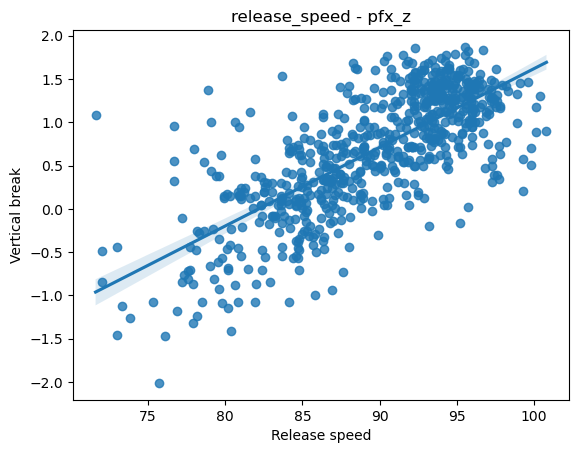

```python
sns.regplot(x='release_speed', y='pfx_z', data=sample_exp_right)

plt.xlabel('Release speed')
plt.ylabel('Vertical break')
plt.title('release_speed - pfx_z')

plt.show()
```

On the other hand, here we observe thata the relation between the spin_axis and pfx_x is not so linear, so this can lead to a more complex model to capure this non linear relation between the features.

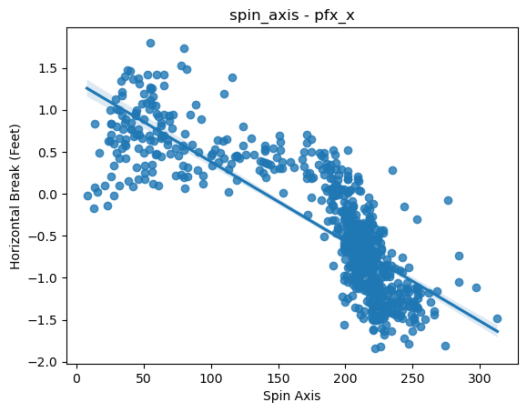

```python
sns.regplot(x='spin_axis', y='pfx_x', data=sample_exp_right)

# Add labels and title
plt.xlabel('Spin Axis')
plt.ylabel('Horizontal Break (Feet)')
plt.title('spin_axis - pfx_x')

# Show the plot
plt.show()
```

## Pitch Break

This graph shows us the difference between the different pitch types and the pitchers arm side (left or right). The red line in the middle of the figure is representing the center of home plate and it also works to represent the "axis of symmetry" between lefties and righties, as we can observe the effect of the ball from each arside is almos perfectly symetric to this line, pitches from each arm side are split by this line.

[figure not shown]

At the same time, we observe the behaivor of the different pitch types. The curveball (Yellow) is a breaking pitch with strong movement towards the floor and the 4-seam Fastball (orange) is a pitch without movement. We clearly see the position of the curveball on the lower part and the fastballs not breaking down at all. At the same time we observa again the symetry of each arm side.

The next video shows and example of the two pitches for comparison:  
https://www.youtube.com/shorts/uDRVt5vQH3I

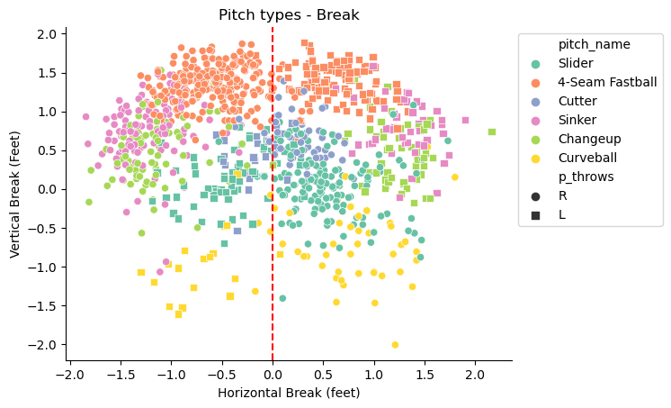

```python
sns.scatterplot(data = sample_exp,
                x = 'pfx_x',
                y = 'pfx_z',
                hue = 'pitch_name',
                style = 'p_throws',
                markers=['o', 's'],
                palette="Set2",
                legend='brief')

sns.despine()
plt.axvline(x=0, color='red', linestyle='--')
plt.title('Pitch types - Break')
plt.xlabel('Horizontal Break (feet)')
plt.ylabel('Vertical Break (Feet)')
plt.legend(bbox_to_anchor=(1, 1), loc='upper left')
plt.show()
```

## Pitch initial velocity

Another important feature to evaluate a pitch is the speed of release, as we can observe differrent pitch types have differente velocities. In order for the ball to move "break", the pitch must be released with different speed and spin velocities.

In both figures we observe that the fastball, ball without movement but fast, has the highes release speed. The curveball not so fast but breaking a lot, has a lower release sepped but the highest spin rate. This is one part of how pitchers manage to throw different pitches and dominate batters.

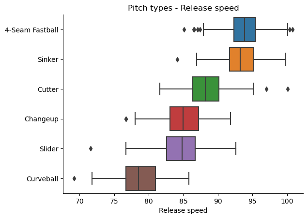

```python
order = sample_exp.groupby('pitch_name')['release_speed'].median().sort_values(ascending=False).index


sns.boxplot(data = sample_exp,
            x = 'release_speed',
            y = 'pitch_name',
            orient = 'h',
            order=order)

sns.despine()
plt.xlabel('Release speed')
plt.ylabel('')
plt.title('Pitch types - Release speed')
plt.show()
```

### Pitch initial spin rate

Spin rate is an important metric in baseball analytics because it can influence a pitcher's ability to control the ball, deceive hitters, and generate movement on different pitches. Pitchers with high spin rates, particularly on breaking balls like curveballs and sliders, often create more movement and can be more challenging for batters to track.

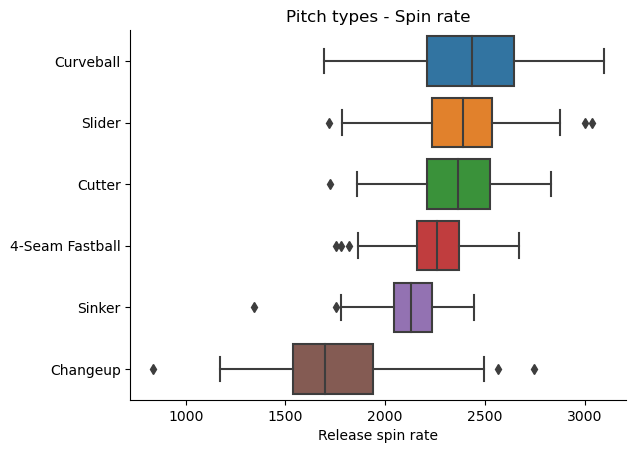

```python
order = sample_exp.groupby('pitch_name')['release_spin_rate'].median().sort_values(ascending=False).index



sns.boxplot(data = sample_exp,
            x = 'release_spin_rate',
            y = 'pitch_name',
            orient = 'h',
            order = order)

sns.despine()
plt.xlabel('Release spin rate')
plt.ylabel('')
plt.title('Pitch types - Spin rate')
plt.show()
```

### Spin Axis - For each side (L and R)

The axis of rotation of the ball is something really important to take into account for this mode, as we can observe in the following image the axis of rotation is almost symetryc between lefties and righties. This figure ilustrates the angel of the axis of rotation of the ball when spinning after the picher releases the ball. A curveball for example, will spin with the same magnitude but in different "sides" for lefties and righties, due to the nature of the arm pitch. We can make the analogy to soccer, in a free kick, left kicker can make the ball move towards one direction and a rigth kicker will make the ball move towards the oposite direction, each one of them is making the ball have a symetric axis of rotation.

**Importance of the rotation:**  
https://www.youtube.com/watch?v=sj7Ly4NaAaQ&t=51s

Axis of rotation:  
https://www.drivelinebaseball.com/2019/09/mastering-the-axis-of-rotation-a-thorough-review-of-spin-axis-in-three-dimensions/

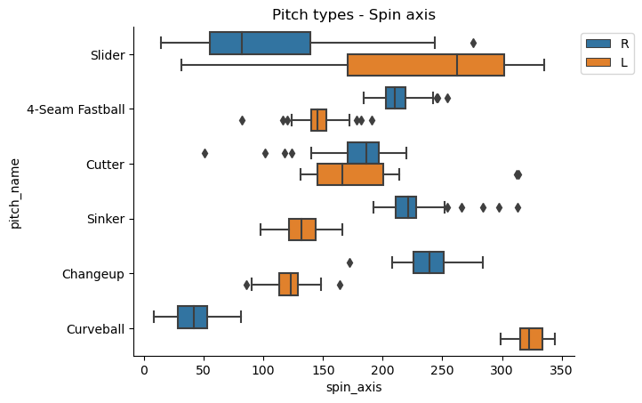

```python
# https://www.drivelinebaseball.com/2019/09/mastering-the-axis-of-rotation-a-thorough-review-of-spin-axis-in-three-dimensions/
sns.boxplot(data = sample_exp,
            x = 'spin_axis',
            y = 'pitch_name',
            hue='p_throws',
            orient = 'h')

sns.despine()
plt.title('Pitch types - Spin axis')
plt.legend(bbox_to_anchor=(1, 1), loc='upper left')
plt.show()
```

# Data Pre- Processing

Now that we have the define the target pitches to classify and filter the promising features, we will start to prepare the data for the model. The current dataset has 340905 entries, as we can see, some columns have missing values, so we have to do some cleanning first.

```python
df_pitches.head()
```

|  | pitch_name | release_speed | release_pos_x | release_pos_z | p_throws | pfx_x | pfx_z | spin_axis | release_spin_rate |
| --- | --- | --- | --- | --- | --- | --- | --- | --- | --- |
| 4 | Cutter | 93.9 | -2.46 | 5.73 | R | -0.09 | 1.59 | 191.0 | 2702.0 |
| 5 | Cutter | 95.0 | -2.38 | 5.75 | R | -0.15 | 1.36 | 192.0 | 2646.0 |
| 6 | Slider | 85.4 | -2.64 | 5.56 | R | 0.88 | -0.04 | 75.0 | 2768.0 |
| 7 | Cutter | 94.4 | -2.41 | 5.71 | R | -0.32 | 1.64 | 197.0 | 2697.0 |
| 12 | 4-Seam Fastball | 97.0 | -1.72 | 5.53 | R | -0.50 | 1.13 | 212.0 | 2167.0 |

```python
df_pitches.info()
```

```
<class 'pandas.core.frame.DataFrame'>
Int64Index: 340905 entries, 4 to 390752
Data columns (total 9 columns):
 #   Column             Non-Null Count   Dtype
---  ------             --------------   -----
 0   pitch_name         340905 non-null  object
 1   release_speed      340869 non-null  float64
 2   release_pos_x      340875 non-null  float64
 3   release_pos_z      340875 non-null  float64
 4   p_throws           340905 non-null  object
 5   pfx_x              340864 non-null  float64
 6   pfx_z              340871 non-null  float64
 7   spin_axis          337984 non-null  float64
 8   release_spin_rate  338010 non-null  float64
dtypes: float64(7), object(2)
memory usage: 26.0+ MB
```

```python
df_pitches.describe()
```

|  | release_speed | release_pos_x | release_pos_z | pfx_x | pfx_z | spin_axis | release_spin_rate |
| --- | --- | --- | --- | --- | --- | --- | --- |
| count | 340869.000000 | 340875.000000 | 340875.000000 | 340864.000000 | 340871.000000 | 337984.000000 | 338010.000000 |
| mean | 89.262511 | -0.778304 | 5.821931 | -0.134666 | 0.685202 | 178.575270 | 2225.137937 |
| std | 5.843797 | 1.828740 | 0.562121 | 0.868519 | 0.720412 | 67.611588 | 304.505031 |
| min | 43.000000 | -4.820000 | 1.040000 | -2.730000 | -2.560000 | 0.000000 | 16.000000 |
| 25% | 85.200000 | -2.080000 | 5.560000 | -0.860000 | 0.240000 | 137.000000 | 2080.000000 |
| 50% | 90.400000 | -1.480000 | 5.880000 | -0.210000 | 0.770000 | 200.000000 | 2248.000000 |
| 75% | 93.900000 | 0.990000 | 6.160000 | 0.550000 | 1.280000 | 221.000000 | 2407.000000 |
| max | 103.300000 | 4.590000 | 7.740000 | 2.270000 | 2.820000 | 360.000000 | 3595.000000 |

Even though this is not the case, we will also drop all rows that do not have a pitch_name defined (our label), this could be due to a bad measurement of the cameras on the field. So in order to avoid noice on the model we will drop them and other incomplete features.

```python
df_pitches = df_pitches.dropna(subset=["pitch_name", "release_speed", "pfx_x", "pfx_z", "spin_axis", "release_spin_rate"])
df_pitches = df_pitches.reset_index(drop=True)
```

## Feature engineering

### Feature - Lefty feature

We will create a feature that indicates if the pitcher is lefty or not, this is important because of the rotation of the ball, the ball from a lefty rotates in the oposite direction than from a righty as we can observe in the "Spin Axis - For each side (L and R)" Figure. So the curveball from a lefty fill have the same "magnitud" but different axis of rotation.

To work with this, we will encode **label encoding** the **p_throws** feature (Lefty or Righty to a 1 or 0). As models work better with numbers than with text.

```python
df_pitches["lefty"] = 0
df_pitches.loc[df_pitches["p_throws"] == 'L', 'lefty'] = 1
```

```python
df_pitches.head()
```

|  | pitch_name | release_speed | release_pos_x | release_pos_z | p_throws | pfx_x | pfx_z | spin_axis | release_spin_rate | lefty |
| --- | --- | --- | --- | --- | --- | --- | --- | --- | --- | --- |
| 0 | Cutter | 93.9 | -2.46 | 5.73 | R | -0.09 | 1.59 | 191.0 | 2702.0 | 0 |
| 1 | Cutter | 95.0 | -2.38 | 5.75 | R | -0.15 | 1.36 | 192.0 | 2646.0 | 0 |
| 2 | Slider | 85.4 | -2.64 | 5.56 | R | 0.88 | -0.04 | 75.0 | 2768.0 | 0 |
| 3 | Cutter | 94.4 | -2.41 | 5.71 | R | -0.32 | 1.64 | 197.0 | 2697.0 | 0 |
| 4 | 4-Seam Fastball | 97.0 | -1.72 | 5.53 | R | -0.50 | 1.13 | 212.0 | 2167.0 | 0 |

### Feature - Power of rotation

To use the same magnitud for both lefties and righties the we create a new feature called **power_rotation** multiplying the **release_spin_rate** and the **pin_axis** , this will give us a mix of the "power and direction" of the spin of the ball and we multiply by -1 (only for lefties) in order to have the same "direction" from both pitchers sides.

```python
df_pitches["power_rotation"] = np.where(df_pitches["lefty"],
        (df_pitches["spin_axis"] -180) * df_pitches["release_spin_rate"] * -1,
        (df_pitches["spin_axis"] -180) * df_pitches["release_spin_rate"]
)
```

Has we can observe in the next figure, all the pitches now have the same "power_rotation", and for both lefties and righties the magnitudes and direction match. Another observation is that only the slider and the curveball have a negative magnitud and it makes sens, those are the only two pitches with a rotation towards home plate, the other ones rotate in the opposite direction.

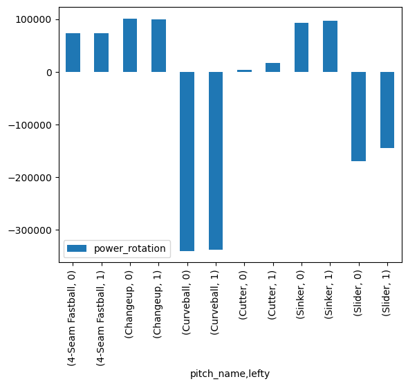

```python
df_pitches.groupby(["pitch_name", "lefty"])[["power_rotation"]].mean().plot(kind="bar")
```

### Feature - Aggressiveness

Another feature that we will evaluate is the "aggressiveness", two pitches can have the same "power of rotation" but not the same speed, so for this feature we are taking into account the "release_speed" of the ball.

```python
df_pitches["aggressiveness"] = df_pitches["power_rotation"] / df_pitches["release_speed"]
```

```python
df_pitches.groupby("pitch_name")["aggressiveness"].mean()
```

```
pitch_name
4-Seam Fastball     778.243394
Changeup           1184.911170
Curveball         -4318.481963
Cutter               70.053608
Sinker             1014.371440
Slider            -1954.641677
Name: aggressiveness, dtype: float64
```

## Encode the labels into numerical values

We will enconde the labels and assign a numeric value to each categoriacal value in the list. This is due to the fact that model works better with numerical values than with text. We also store the "mapping" between the category and the actual value so later we can "remap" the output to a more human friendly answer.

```python
categories = df_pitches["pitch_name"].astype('category')
df_pitches["pitch_code"] = categories.cat.codes
pitch_type_cat = categories.cat.categories
pitch_type_cat
```

```
Index(['4-Seam Fastball', 'Changeup', 'Curveball', 'Cutter', 'Sinker',
       'Slider'],
      dtype='object')
```

```python
df_pitches["pitch_code"].value_counts()
```

```
0    122639
5     65979
4     54330
1     42274
2     27443
3     25308
Name: pitch_code, dtype: int64
```

**This dict contains the mapping from the name (String) of the pitch to the categoty (Numeric) of the pitch**

```python
pitch_type_mapping = df_pitches.set_index('pitch_code').to_dict()['pitch_name']
pitch_type_mapping
```

```
{3: 'Cutter',
 5: 'Slider',
 0: '4-Seam Fastball',
 4: 'Sinker',
 1: 'Changeup',
 2: 'Curveball'}
```

```python
df_pitches.head()
```

|  | pitch_name | release_speed | release_pos_x | release_pos_z | p_throws | pfx_x | pfx_z | spin_axis | release_spin_rate | lefty | power_rotation | aggressiveness | pitch_code |
| --- | --- | --- | --- | --- | --- | --- | --- | --- | --- | --- | --- | --- | --- |
| 0 | Cutter | 93.9 | -2.46 | 5.73 | R | -0.09 | 1.59 | 191.0 | 2702.0 | 0 | 29722.0 | 316.528222 | 3 |
| 1 | Cutter | 95.0 | -2.38 | 5.75 | R | -0.15 | 1.36 | 192.0 | 2646.0 | 0 | 31752.0 | 334.231579 | 3 |
| 2 | Slider | 85.4 | -2.64 | 5.56 | R | 0.88 | -0.04 | 75.0 | 2768.0 | 0 | -290640.0 | -3403.278689 | 5 |
| 3 | Cutter | 94.4 | -2.41 | 5.71 | R | -0.32 | 1.64 | 197.0 | 2697.0 | 0 | 45849.0 | 485.688559 | 3 |
| 4 | 4-Seam Fastball | 97.0 | -1.72 | 5.53 | R | -0.50 | 1.13 | 212.0 | 2167.0 | 0 | 69344.0 | 714.886598 | 0 |

```python
df_pitches.isnull().sum()
```

```
pitch_name           0
release_speed        0
release_pos_x        0
release_pos_z        0
p_throws             0
pfx_x                0
pfx_z                0
spin_axis            0
release_spin_rate    0
lefty                0
power_rotation       0
aggressiveness       0
pitch_code           0
dtype: int64
```

### Features and label

First we define the features and the label that the model will use. Here are all posible features, from these we will select the ones that have more predictive power.

```python
features = ["release_speed", "release_pos_x", "release_pos_z", "pfx_x", "pfx_z", "spin_axis", "release_spin_rate", "lefty", "power_rotation", "aggressiveness"]
label = "pitch_code"
```

### Prepare the sets (Training set, Validation set, Test set)

The initial aproach for this problem will be

- **Training test** : 60% of the data.
- **Validation test** : 20% of the data.
- **Test test** : 20% of the data.

```python
X_train, X_temp, y_train, y_temp = train_test_split(df_pitches.loc[:, features], df_pitches[label], test_size=0.4, random_state=42)
X_val, X_test, y_val, y_test = train_test_split(X_temp, y_temp, test_size=0.5, random_state=42)
```

### Features prediction power

https://www.youtube.com/watch?v=cw4qG9ePZ9Y

```python
X_train.head()
```

|  | release_speed | release_pos_x | release_pos_z | pfx_x | pfx_z | spin_axis | release_spin_rate | lefty | power_rotation | aggressiveness |
| --- | --- | --- | --- | --- | --- | --- | --- | --- | --- | --- |
| 199229 | 98.3 | -2.16 | 6.02 | -1.52 | 0.91 | 222.0 | 2074.0 | 0 | 87108.0 | 886.144456 |
| 179824 | 94.5 | -2.99 | 5.34 | -1.39 | 0.12 | 229.0 | 2132.0 | 0 | 104468.0 | 1105.481481 |
| 333835 | 86.5 | -1.43 | 7.09 | 0.05 | 0.63 | 162.0 | 2286.0 | 0 | -41148.0 | -475.699422 |
| 1734 | 87.2 | -1.80 | 5.29 | 0.29 | 0.63 | 214.0 | 1913.0 | 0 | 65042.0 | 745.894495 |
| 291563 | 92.4 | -2.30 | 6.37 | -0.63 | 1.83 | 206.0 | 2151.0 | 0 | 55926.0 | 605.259740 |

```python
model = RandomForestClassifier()
model.fit(X_train, y_train)
```

```
RandomForestClassifier()
```

As we can observe the two features created in the feature engineering step are on the top 5 of the features with more predictive power. At the top as we expected is the speed and vertical break, these are a very important features and peculiar for most of the pitches, so here we have another checkpoint aproved to validate the "theory" of the problem.

```python
feat_importance = pd.DataFrame({
    "Feature": model.feature_names_in_,
    "Importance": model.feature_importances_
})
feat_importance.sort_values(by='Importance', ascending=False)
```

|  | Feature | Importance |
| --- | --- | --- |
| 4 | pfx_z | 0.246536 |
| 0 | release_speed | 0.182090 |
| 3 | pfx_x | 0.124027 |
| 8 | power_rotation | 0.106659 |
| 9 | aggressiveness | 0.102700 |
| 6 | release_spin_rate | 0.093708 |
| 1 | release_pos_x | 0.049020 |
| 2 | release_pos_z | 0.045711 |
| 5 | spin_axis | 0.045137 |
| 7 | lefty | 0.004413 |

Here we will have the combination of the features implemented in the model, during the development of the model this array can change to evaluate different results. Next we show the best two iterations and the corresponding performance values for the two models (Logistic regression and Random Forest) and their metrics, we will dive deeper into each one in the next step.

```python
# 1st best combination
# Logistic regression: ACC: 0.8110807012352985 - LOSS: 0.514668731751717
# Random Forest: ACC: 0.8932317479103484 - LOSS: 0.3558759092162709
model_feat = ["release_speed", "pfx_x", "pfx_z", "release_spin_rate", "power_rotation", "aggressiveness"]

# 2nd best combination
# Logistic regression: ACC: 0.7881795990827724 - LOSS: 0.5967352610759848
# Random Forest: ACC: 0.8718248391153192 - LOSS: 0.458606064083645
#model_feat = ["release_speed", "pfx_x", "pfx_z", "power_rotation", "aggressiveness"]

# 3rd best combination
# Logistic regression: ACC: 0.7901176122494268 - LOSS: 0.5820634205249197
# Random Forest: ACC: 0.8609956357718767 - LOSS: 0.5057296038599691
#model_feat = ["release_speed", "pfx_x", "pfx_z", "release_spin_rate"]
```

## Scale the values

Before we input the features into the model, we will apply a transformation, **StandardScaler** , Machile Learning models work better with standardize data, we scale both, the training and validation data.

https://scikit-learn.org/stable/modules/preprocessing.html

```python
scaler = preprocessing.StandardScaler().fit(X_train.loc[:, model_feat])
X_train_scaled = pd.DataFrame(scaler.transform(X_train.loc[:, model_feat]))

scaler_val = preprocessing.StandardScaler().fit(X_val.loc[:, model_feat])
X_val_scaled = pd.DataFrame(scaler_val.transform(X_val.loc[:, model_feat]), index=X_val.index, columns=X_val.loc[:, model_feat].columns)
```

## Modeling

Once defined the features, we will start with the modeling section of the problem. In this section two models will be put to the test and we will compare wich one performs better, the following models are propose:

- **Logistic regression** : https://scikit-learn.org/stable/modules/generated/sklearn.linear_model.LogisticRegression.html
- **Random forest** : https://scikit-learn.org/stable/modules/generated/sklearn.ensemble.RandomForestClassifier.html

## Logistic Regression

### Training the model

We start by trining the logistic regression model with the training data, so it can "learn" about the data. This model fits the probabilistic function that indicates the probability of some output category being true, in this case the outputs are the pitch types, so the model will give us a table with the probability of each pitch being the correct one.

```python
# TRAIN THE MODEL - Training set
log_model = LogisticRegression()
log_model.fit(X_train_scaled, y_train)
```

```
LogisticRegression()
```

### Validate the model

```python
# VALIDATE THE MODEL - Validation set
val_log_out = pd.DataFrame(log_model.predict_proba(X_val_scaled), index=X_val_scaled.index, columns=pitch_type_cat)
val_log_out.head()
```

|  | 4-Seam Fastball | Changeup | Curveball | Cutter | Sinker | Slider |
| --- | --- | --- | --- | --- | --- | --- |
| 319922 | 2.401892e-01 | 1.378091e-01 | 5.246360e-06 | 2.589695e-01 | 2.755085e-01 | 0.087518 |
| 140564 | 3.224731e-05 | 9.739861e-01 | 1.639615e-04 | 1.802704e-03 | 3.725189e-03 | 0.020290 |
| 324653 | 1.175188e-24 | 2.215327e-14 | 9.993948e-01 | 7.912519e-10 | 1.506993e-17 | 0.000605 |
| 115439 | 1.172434e-14 | 1.949461e-11 | 3.871178e-01 | 2.027815e-03 | 1.909169e-11 | 0.610854 |
| 271617 | 1.813946e-03 | 9.654203e-01 | 5.064070e-08 | 2.000665e-04 | 3.226373e-02 | 0.000302 |

### Output - Validation Set

Here we show the "Big picture" of the result, we show for each entry (pitch):

- **INPUT** : Features
- **OUTPUT** : Probability for each pitch to be the right prediction
- **LABEL** : Actual pitch type
- **PREDICTION** : Pitch predicted by the model

```python
# VALIDATION LABELS - Rename "remap" columns
val_labels = pd.DataFrame(pitch_type_cat[y_val.values], index = y_val.index, columns=["pitch_type"])

# Concat Input - probability output - label
validation_res = pd.concat([X_val_scaled, val_log_out, val_labels], axis=1)

# Select higher probability for each pitch (classification output)
validation_res["pitch_type_pred"] = validation_res.loc[:, '4-Seam Fastball':'Slider'].idxmax(axis=1)
validation_res.head()
```

|  | release_speed | pfx_x | pfx_z | release_spin_rate | power_rotation | aggressiveness | 4-Seam Fastball | Changeup | Curveball | Cutter | Sinker | Slider | pitch_type | pitch_type_pred |
| --- | --- | --- | --- | --- | --- | --- | --- | --- | --- | --- | --- | --- | --- | --- |
| 319922 | -0.141874 | 1.547808 | 0.262652 | -0.475150 | 0.537884 | 0.546702 | 2.401892e-01 | 1.378091e-01 | 5.246360e-06 | 2.589695e-01 | 2.755085e-01 | 0.087518 | Sinker | Sinker |
| 140564 | -1.163532 | 0.027873 | -0.484936 | -1.885213 | 0.474769 | 0.517621 | 3.224731e-05 | 9.739861e-01 | 1.639615e-04 | 1.802704e-03 | 3.725189e-03 | 0.020290 | Slider | Changeup |
| 324653 | -2.917379 | 1.190853 | -2.907673 | 0.807023 | -2.160625 | -2.448160 | 1.175188e-24 | 2.215327e-14 | 9.993948e-01 | 7.912519e-10 | 1.506993e-17 | 0.000605 | Curveball | Curveball |
| 115439 | -1.538140 | 1.916276 | -1.190990 | 2.240040 | -2.169330 | -2.202387 | 1.172434e-14 | 1.949461e-11 | 3.871178e-01 | 2.027815e-03 | 1.909169e-11 | 0.610854 | Curveball | Slider |
| 271617 | -0.329178 | -1.296312 | 0.054989 | -2.377095 | 0.602463 | 0.613957 | 1.813946e-03 | 9.654203e-01 | 5.064070e-08 | 2.000665e-04 | 3.226373e-02 | 0.000302 | Changeup | Changeup |

### Measure the model

#### Accuracy

The accuracy of a classification model tell us how many time the model classified correctly the entries compared to the total number of entries, in other words, out of 100 Cutters how many where classified as cutters.

**Description:** https://developers.google.com/machine-learning/crash-course/classification/accuracy

**Scikit-learn function:** https://scikit-learn.org/stable/modules/generated/sklearn.metrics.accuracy_score.html

```python
# produce accuracy and log loss metrics to evaluate model performance
acc_lg = accuracy_score(validation_res['pitch_type'], validation_res.loc[:, 'pitch_type_pred'])
acc_lg
```

```
0.8110807012352985
```

### Loss

With the loss function we can have an indicator of the error between the prediction output and the correct target value. This means that the lower ther loss the closer the model is "missing" in comparison to the target value.

Here we observe a loss of 0.51, so when we fail we are failing considerably high. The prediction that the model gave is not close to the target value.

**Scikit-learn function:** https://scikit-learn.org/stable/modules/generated/sklearn.metrics.log_loss.html

```python
loss_lg = log_loss(validation_res['pitch_type'], validation_res.loc[:, '4-Seam Fastball': 'Slider'])
loss_lg
```

```
0.514668731751717
```

### Conclusion

The logistic regression model has a acuracy of 81% wich is very good and a 0.51 loss, this model is a great first iteration to the problem and has set the line to the next model, so lets see how Random Forest performs.

## Random Forest

For this model we will follow almost the same steps as for logistic regression, something to take into account is that this model is more complex than Logistic regression.

### Training the model

We start by trining the Random Fores model with the training data, so it can "learn" about the data. Here all the sets are the same as the once used in the logistic regression model.

```python
# TRAIN THE MODEL - Training set
rf_model = RandomForestClassifier()
rf_model.fit(X_train_scaled, y_train)
```

```
RandomForestClassifier()
```

### Validate the model

Once the model is trained, we proceed to "show" the validation set to evaluate the metrics of the model. The next table shows the probability of each pitch type due each features of the row, to select the most probable pitch we only have to select the highest probability of all (Max function).

```python
df_val_rf = pd.DataFrame(rf_model.predict_proba(X_val_scaled), index = X_val_scaled.index, columns = pitch_type_cat)
df_val_rf.head()
```

|  | 4-Seam Fastball | Changeup | Curveball | Cutter | Sinker | Slider |
| --- | --- | --- | --- | --- | --- | --- |
| 319922 | 0.05 | 0.04 | 0.00 | 0.00 | 0.91 | 0.00 |
| 140564 | 0.00 | 0.25 | 0.00 | 0.02 | 0.00 | 0.73 |
| 324653 | 0.00 | 0.00 | 1.00 | 0.00 | 0.00 | 0.00 |
| 115439 | 0.00 | 0.00 | 0.35 | 0.00 | 0.00 | 0.65 |
| 271617 | 0.00 | 1.00 | 0.00 | 0.00 | 0.00 | 0.00 |

### Output visualization - Validation Set

Here we show the "Big picture" of the result, we show for each entry (pitch):

- **INPUT** : Features
- **OUTPUT** : Probability for each pitch to be the right prediction
- **LABEL** : Actual pitch type
- **PREDICTION** : Pitch predicted by the model

```python
# VALIDATION LABELS - Rename "remap" columns
val_labels_rf = pd.DataFrame(pitch_type_cat[y_val.values], index = y_val.index, columns=["pitch_type"])

# Concat Input - probability output - label
validation_res_rf = pd.concat([X_val_scaled, df_val_rf, val_labels_rf], axis=1)

# Select higher probability for each pitch (classification output)
validation_res_rf["pitch_type_pred"] = validation_res_rf.loc[:, '4-Seam Fastball':'Slider'].idxmax(axis=1)
validation_res_rf.head()
```

|  | release_speed | pfx_x | pfx_z | release_spin_rate | power_rotation | aggressiveness | 4-Seam Fastball | Changeup | Curveball | Cutter | Sinker | Slider | pitch_type | pitch_type_pred |
| --- | --- | --- | --- | --- | --- | --- | --- | --- | --- | --- | --- | --- | --- | --- |
| 319922 | -0.141874 | 1.547808 | 0.262652 | -0.475150 | 0.537884 | 0.546702 | 0.05 | 0.04 | 0.00 | 0.00 | 0.91 | 0.00 | Sinker | Sinker |
| 140564 | -1.163532 | 0.027873 | -0.484936 | -1.885213 | 0.474769 | 0.517621 | 0.00 | 0.25 | 0.00 | 0.02 | 0.00 | 0.73 | Slider | Slider |
| 324653 | -2.917379 | 1.190853 | -2.907673 | 0.807023 | -2.160625 | -2.448160 | 0.00 | 0.00 | 1.00 | 0.00 | 0.00 | 0.00 | Curveball | Curveball |
| 115439 | -1.538140 | 1.916276 | -1.190990 | 2.240040 | -2.169330 | -2.202387 | 0.00 | 0.00 | 0.35 | 0.00 | 0.00 | 0.65 | Curveball | Slider |
| 271617 | -0.329178 | -1.296312 | 0.054989 | -2.377095 | 0.602463 | 0.613957 | 0.00 | 1.00 | 0.00 | 0.00 | 0.00 | 0.00 | Changeup | Changeup |

### Measure the model

#### Accuracy

Here we observe that a more complex model like Random Forest is giving us a better performance in terms of accuracy. We obtaine a 89% of correct classifications with this model wich is a really good model.

**Scikit-learn function:** https://scikit-learn.org/stable/modules/generated/sklearn.metrics.accuracy_score.html

```python
# produce accuracy metric to evaluate performance
acc_rf = accuracy_score(validation_res_rf['pitch_type'], validation_res_rf.loc[:, 'pitch_type_pred'])
acc_rf
```

```
0.8928766920630224
```

### Loss

At the same time not only the accuray improved but also we were able to reduce the loss, now when we miss we are missing close to the target value. This is something that every system will have to deal with, in MLB the variety of pitching styles lead to have very similar pitch metrics and this will make two different pitches look really familiar.

**Scikit-learn function:** https://scikit-learn.org/stable/modules/generated/sklearn.metrics.log_loss.html

```python
loss_rf = log_loss(validation_res_rf['pitch_type'], validation_res_rf.loc[:, '4-Seam Fastball': 'Slider'])
loss_rf
```

```
0.3601046811933963
```

## Model selection

After training the models we now will compare the metrics to select the best one, the next table shows the performance of each model evaluating both accuracy and loss.

We observe that the Random Forest model has a better score on the accuracy by 8 points and has better score on the loss for more than 15 points. This is a clear win for the Random Forest model. Once we selected the best model for the problem, now we are going to test this model with the test set.

```python
metrics = pd.DataFrame({
    "Model": ["Logistic Regression", "Random Forest"],
    "Accuracy": [acc_lg, acc_rf],
    "Loss": [loss_lg, loss_rf]
})

metrics.sort_values(by="Accuracy", ascending=False)
```

|  | Model | Accuracy | Loss |
| --- | --- | --- | --- |
| 1 | Random Forest | 0.892877 | 0.360105 |
| 0 | Logistic Regression | 0.811081 | 0.514669 |

## Evaluate model performance - Test Set

On this last step we will evaluate the model **rf_model** (Random Forest) one last time with unseen data (test set) to validate one last time the performance of the model before going "live to production".

### Standardize test set

```python
scaler_val = preprocessing.StandardScaler().fit(X_test.loc[:, model_feat])
X_test_scaled = pd.DataFrame(scaler_val.transform(X_test.loc[:, model_feat]), index=X_test.index, columns=X_test.loc[:, model_feat].columns)
```

### Predict values

```python
df_test = pd.DataFrame(rf_model.predict_proba(X_test_scaled.loc[:, model_feat]), index = X_test_scaled.index, columns = pitch_type_cat)
df_test.head()
```

|  | 4-Seam Fastball | Changeup | Curveball | Cutter | Sinker | Slider |
| --- | --- | --- | --- | --- | --- | --- |
| 175169 | 0.00 | 0.00 | 0.18 | 0.0 | 0.00 | 0.82 |
| 137767 | 0.01 | 0.02 | 0.00 | 0.0 | 0.97 | 0.00 |
| 56047 | 0.18 | 0.00 | 0.00 | 0.0 | 0.82 | 0.00 |
| 77466 | 0.00 | 0.00 | 0.99 | 0.0 | 0.00 | 0.01 |
| 198882 | 0.00 | 0.00 | 0.00 | 1.0 | 0.00 | 0.00 |

### Output

```python
# VALIDATION LABELS - Rename "remap" columns
test_labels = pd.DataFrame(pitch_type_cat[y_test.values], index = y_test.index, columns=["pitch_type"])

# Concat Input - probability output - label
test_out = pd.concat([X_test, df_test, test_labels], axis=1)

# Select higher probability for each pitch (classification output)
test_out["pitch_type_pred"] = test_out.loc[:, '4-Seam Fastball':'Slider'].idxmax(axis=1)
test_out.head()
```

|  | release_speed | release_pos_x | release_pos_z | pfx_x | pfx_z | spin_axis | release_spin_rate | lefty | power_rotation | aggressiveness | 4-Seam Fastball | Changeup | Curveball | Cutter | Sinker | Slider | pitch_type | pitch_type_pred |
| --- | --- | --- | --- | --- | --- | --- | --- | --- | --- | --- | --- | --- | --- | --- | --- | --- | --- | --- |
| 175169 | 83.5 | -1.16 | 5.80 | 0.28 | -0.21 | 47.0 | 2628.0 | 0 | -349524.0 | -4185.916168 | 0.00 | 0.00 | 0.18 | 0.0 | 0.00 | 0.82 | Slider | Slider |
| 137767 | 97.3 | -2.26 | 4.36 | -1.43 | -0.37 | 252.0 | 2174.0 | 0 | 156528.0 | 1608.715313 | 0.01 | 0.02 | 0.00 | 0.0 | 0.97 | 0.00 | Sinker | Sinker |
| 56047 | 94.4 | -0.99 | 5.98 | -0.90 | 1.06 | 205.0 | 2405.0 | 0 | 60125.0 | 636.917373 | 0.18 | 0.00 | 0.00 | 0.0 | 0.82 | 0.00 | Sinker | Sinker |
| 77466 | 78.9 | -1.65 | 5.97 | 0.94 | -1.30 | 24.0 | 2511.0 | 0 | -391716.0 | -4964.714829 | 0.00 | 0.00 | 0.99 | 0.0 | 0.00 | 0.01 | Curveball | Curveball |
| 198882 | 100.8 | -0.83 | 6.05 | 0.44 | 0.87 | 190.0 | 2543.0 | 0 | 25430.0 | 252.281746 | 0.00 | 0.00 | 0.00 | 1.0 | 0.00 | 0.00 | Cutter | Cutter |

### Metrics

#### Accuracy

```python
# produce accuracy metric to evaluate performance
acc_test = accuracy_score(test_out['pitch_type'], test_out.loc[:, 'pitch_type_pred'])
acc_test
```

```
0.8933205118721799
```

### Loss

```python
loss_test = log_loss(test_out['pitch_type'], test_out.loc[:, '4-Seam Fastball': 'Slider'])
loss_test
```

```
0.35022822555629274
```

We observe the same expected performance metrics, this is something good, our model is stable and robust when working with new data. To get a couple of insights for the next iterations of the model, we will do a quick analysis on where our model is laking accuracy.

## Evaluate hardes pitches to classify

Next we are going to find out where our model is lacking precision, we will evaluate how accurate the model can classify each pitch type.

As we can see all pitches are above 80% of accuracy the lowest one is the cutter with aprox 60%. This can be due to the nature of the pitch, its really similay to all pitches in tems of spin rate and also in speed, this can lead the model to misclassify the cutter so many times.

```
pitch_type
4-Seam Fastball    0.958086
Changeup           0.927564
Curveball          0.854685
Cutter             0.618125
Sinker             0.886566
Slider             0.878910
dtype: float64
```

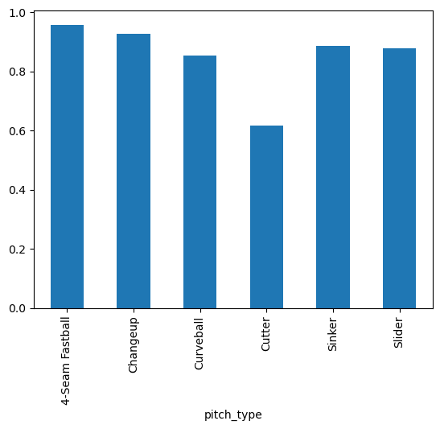

```python
pitch_prediction = test_out[["pitch_type", "pitch_type_pred"]]
pitch_prediction.groupby("pitch_type").apply(lambda group: sum(group['pitch_type'] == group['pitch_type_pred']) / group.shape[0]).plot(kind="bar")
pitch_prediction.groupby("pitch_type").apply(lambda group: sum(group['pitch_type'] == group['pitch_type_pred']) / group.shape[0])
```

```python
test_out[["pitch_type", "pitch_type_pred"]].shape
```

```
(67595, 2)
```

### Final Reslt - SUCCESS

As we can see the model is still accurate when working with an unseen dataset, this is great, our model is accurate and robust. Once we tested the model it is ready to continue to production where it will see more data and classify it during real games.

In the following lines we are "simulating" a real period of new data for out model, in the next line we query data from X to Y period of time to use the model "During real games". You can select the period of time (for memory prorposes make it short, less than 1 year) and try the model. Here we will not describe the process as we already know it from the "development" section and we will only focuse on the result.

## Ready for production

```python
# download dataset
df_live = bb.statcast(start_dt='2021-06-01', end_dt='2021-06-10')
```

```
This is a large query, it may take a moment to complete
```

```python
df_live.head()
```

|  | pitch_type | game_date | release_speed | release_pos_x | release_pos_z | player_name | batter | pitcher | events | description | ... | fld_score | post_away_score | post_home_score | post_bat_score | post_fld_score | if_fielding_alignment | of_fielding_alignment | spin_axis | delta_home_win_exp | delta_run_exp |
| --- | --- | --- | --- | --- | --- | --- | --- | --- | --- | --- | --- | --- | --- | --- | --- | --- | --- | --- | --- | --- | --- |
| 1995 | FF | 2021-06-10 | 97.8 | 0.37 | 6.16 | Chapman, Aroldis | 443558 | 547973 | home_run | hit_into_play | ... | 5 | 5 | 7 | 7 | 5 | Standard | Standard | 151 | 0.292 | 1.58 |
| 2056 | FF | 2021-06-10 | 96.5 | 0.44 | 6.07 | Chapman, Aroldis | 553902 | 547973 | single | hit_into_play | ... | 5 | 5 | 5 | 5 | 5 | Standard | Standard | 149 | 0.074 | 0.404 |
| 2185 | FF | 2021-06-10 | 95.5 | 0.29 | 6.03 | Chapman, Aroldis | 518626 | 547973 | home_run | hit_into_play | ... | 5 | 5 | 5 | 5 | 5 | Standard | Standard | 155 | 0.457 | 1.523 |
| 2224 | FF | 2021-06-10 | 97.6 | 0.53 | 6.05 | Chapman, Aroldis | 518626 | 547973 | NaN | ball | ... | 5 | 5 | 3 | 3 | 5 | Standard | Standard | 151 | 0.0 | 0.057 |
| 2314 | FF | 2021-06-10 | 96.1 | 0.27 | 6.07 | Chapman, Aroldis | 593871 | 547973 | single | hit_into_play | ... | 5 | 5 | 3 | 3 | 5 | Standard | Standard | 154 | 0.09 | 0.25 |

5 rows × 92 columns

### Data Pre-processing

```python
# Reduction of Features
features = ["release_speed", "pfx_x", "pfx_z", "release_spin_rate", "spin_axis", "pitch_name", "p_throws"]
df_live = df_live[features]


# Data cleaning
df_live = df_live.dropna(subset=["pitch_name", "release_speed", "pfx_x", "pfx_z", "spin_axis", "release_spin_rate"])
df_live = df_live.reset_index(drop=True)


# Feature engineering
# Is lefty
df_live["lefty"] = 0
df_live.loc[df_live["p_throws"] == 'L', 'lefty'] = 1


#  Power rotation
df_live["power_rotation"] = np.where(df_live["lefty"],
        (df_live["spin_axis"] -180) * df_live["release_spin_rate"] * -1,
        (df_live["spin_axis"] -180) * df_live["release_spin_rate"]
)

# Aggresivness
df_live["aggressiveness"] = df_live["power_rotation"] / df_live["release_speed"]


# Pitch encoding
df_live = df_live[df_live["pitch_name"].isin(["4-Seam Fastball", "Slider", "Sinker", "Changeup", "Curveball", "Cutter"])]
categories = df_live["pitch_name"].astype('category')
df_live["pitch_code"] = categories.cat.codes
pitch_type_cat = categories.cat.categories



# Features and labels
live_features  = ["release_speed", "pfx_x", "pfx_z", "release_spin_rate", "power_rotation", "aggressiveness"]
live_label = "pitch_code"
```

### Feature standarization

```python
live_scal = preprocessing.StandardScaler().fit(df_live.loc[:, live_features])
x_live_scal = pd.DataFrame(live_scal.transform(df_live.loc[:, live_features]), index=df_live.loc[:, live_features].index, columns=df_live.loc[:, live_features].columns)
y_live_label = df_live.loc[:, live_label]
```

### Input into the model

```python
# Model
live_pred = pd.DataFrame(rf_model.predict_proba(x_live_scal), index = x_live_scal.index, columns=pitch_type_cat)


# VALIDATION LABELS - Rename "remap" columns
live_labels = pd.DataFrame(pitch_type_cat[y_live_label.values], index = y_live_label.index, columns=["pitch_type"])

# Concat Input - probability output - label
live_out = live_labels

live_out.head()

# Select higher probability for each pitch (classification output)
live_out["pitch_type_pred"] = live_pred.idxmax(axis=1)
live_out.head(50)
```

|  | pitch_type | pitch_type_pred |
| --- | --- | --- |
| 0 | 4-Seam Fastball | 4-Seam Fastball |
| 1 | 4-Seam Fastball | 4-Seam Fastball |
| 2 | 4-Seam Fastball | 4-Seam Fastball |
| 3 | 4-Seam Fastball | 4-Seam Fastball |
| 4 | 4-Seam Fastball | 4-Seam Fastball |
| 5 | 4-Seam Fastball | 4-Seam Fastball |
| 6 | 4-Seam Fastball | 4-Seam Fastball |
| 7 | Slider | Slider |
| 8 | Slider | Slider |
| 9 | Slider | Cutter |
| 10 | Slider | Cutter |
| 11 | Slider | Slider |
| 12 | Changeup | Changeup |
| 13 | 4-Seam Fastball | 4-Seam Fastball |
| 14 | Changeup | Changeup |
| 15 | 4-Seam Fastball | 4-Seam Fastball |
| 16 | Changeup | Changeup |
| 17 | Changeup | Changeup |
| 18 | Changeup | Changeup |
| 19 | Slider | Cutter |
| 20 | 4-Seam Fastball | 4-Seam Fastball |
| 21 | 4-Seam Fastball | 4-Seam Fastball |
| 22 | Curveball | Slider |
| 23 | 4-Seam Fastball | 4-Seam Fastball |
| 24 | Curveball | Slider |
| 25 | 4-Seam Fastball | 4-Seam Fastball |
| 26 | 4-Seam Fastball | 4-Seam Fastball |
| 27 | 4-Seam Fastball | 4-Seam Fastball |
| 28 | Curveball | Slider |
| 29 | Curveball | Slider |
| 30 | 4-Seam Fastball | 4-Seam Fastball |
| 31 | 4-Seam Fastball | 4-Seam Fastball |
| 32 | 4-Seam Fastball | 4-Seam Fastball |
| 33 | 4-Seam Fastball | 4-Seam Fastball |
| 34 | Curveball | Slider |
| 35 | 4-Seam Fastball | 4-Seam Fastball |
| 36 | 4-Seam Fastball | 4-Seam Fastball |
| 37 | 4-Seam Fastball | 4-Seam Fastball |
| 38 | 4-Seam Fastball | 4-Seam Fastball |
| 39 | Slider | Slider |
| 40 | 4-Seam Fastball | 4-Seam Fastball |
| 41 | 4-Seam Fastball | 4-Seam Fastball |
| 42 | Slider | Slider |
| 43 | 4-Seam Fastball | 4-Seam Fastball |
| 44 | 4-Seam Fastball | 4-Seam Fastball |
| 45 | 4-Seam Fastball | 4-Seam Fastball |
| 46 | Slider | Curveball |
| 47 | 4-Seam Fastball | 4-Seam Fastball |
| 48 | Slider | Curveball |
| 49 | 4-Seam Fastball | 4-Seam Fastball |

## Conclusion

After working on this project we can conclude:

- Random fores model performs better than the logistic regression model as expected, Random Forest is a more complex model.
- This model is highly accurate for predicting pitches with unseen data (Close to 90%).
- The most important features are the once reprecenting the speed, rotation and break of the ball.

### Recomendations

For the next iterations of this model is recomended to dig further in developing a efficient model to distinguish "really similar pitches" as we saw on the **Evaluate hardes pitches to classify** section is har for the model to classify correctlly similar movement pitches like the slider, the cutter and the curveball, in a real game the breake difference between these pitches can be a couple on centimeters and it depends on each pitchers arms side, release point, pitching style, etc. Its recomended to work on the feature engineering step to campure all that information and make the model more accurate.

Its also recommended to explore another models of classification to validate if one of them is more efficient (there is always room for improvement).

### Self-critical assessment

During this project the most complex part was the feature analysis and engineering steps, here is where the real value of the project is. Selecting/creating the features and defining wich onces can give the model the complete "context" and information about the problem to accuratly classify the pitches. At the same time here is where the project could be improved, even thoug we have a good accuracy 90%, in the feature engineering step we can improve the "missing" information for the model to correcly classify that 10% left.

I think that this project needs spatial imagination and understanding, because the problem and all of the features are taken and representing a 3D fenomena, so having that spatial ability can really help to connect all the dots (feature) together, also having a couple of oranges as baseballs can help with the visualization.